# 250329_CrypticPSIfill

Irika Sinha

2025-02-04

## Purpose

The purpose of this script is to take the file with manually identified cryptic exon coordinates and use those coordinates to identify left and right junction PSIs in the different conditions for i3N.

## Packages

Load packages needed for this file.

```r
CRANpackages <- c("tidyverse", "ggplot2", "ggpubr", "ggstats","BiocManager",
                  "viridis","pheatmap","readxl", "data.table", "rtracklayer")

for(i in CRANpackages){
  if(!(i %in% rownames(installed.packages()))){
    install.packages(pkgs = i)
  }
  library(package = i, character.only = T, quietly = T)
  rm(i)
}
```

[output not shown]

```r
#library("clusterProfiler","org.Hs.eg.db")
```

## Create a dataframe of splice junction counts

.sj files generated from STAR alignment of reads and include splice junction information for each sample. Create a new dataframe with splice junction counts from each sample for relevant junctions

```r
### Load cryptic files
cryptic_df <- readxl::read_xlsx("/Users/irika/Library/CloudStorage/OneDrive-JohnsHopkins/WongLing/Papers/NMD/02_Revisions/TDP43-NMD_Tables_Main.xlsx", sheet = 2)[,1:19]
skiptic_df <- readxl::read_xlsx("/Users/irika/Library/CloudStorage/OneDrive-JohnsHopkins/WongLing/Papers/NMD/02_Revisions/TDP43-NMD_Tables_Main.xlsx", sheet = 3)[,1:6]

## Clean up junctions - cryptic_df
for(i in c(5:6,18:19)){
  cryptic_df[,i] = apply(cryptic_df[,i],2,function(x) gsub(pattern = ",", replacement = "", x = x))
  cryptic_df[,i] = apply(cryptic_df[,i],2,function(x) gsub(pattern = " ", replacement = "", x = x))
  rm(i)
}

## Clean up junctions - skiptic_df
for(i in c(3:5)){
  skiptic_df[,i] = apply(skiptic_df[,i],2,function(x) gsub(pattern = ",", replacement = "", x = x))
  skiptic_df[,i] = apply(skiptic_df[,i],2,function(x) gsub(pattern = " ", replacement = "", x = x))
  rm(i)
}

## Create a list of unique junctions being queried
uniqueJunctions = unique(c(cryptic_df$canonical_splice_junction,
                         cryptic_df$left_junction, cryptic_df$right_junction,
                         skiptic_df$left_canonical_junction, skiptic_df$right_canonical_junction,
                         skiptic_df$skiptic_junction))
uniqueJunctions = unlist(as.list(str_split(uniqueJunctions,";")))

## Create empty dataframe to populate with splice junction counts
finaldf <- data.frame()

## Load .sj files and merge into one large data frame
# Filter to splice junctions being queried
sj_wd <- "/Users/irika/Library/CloudStorage/OneDrive-JohnsHopkins/WongLing/Scripts/250106_CrypticCoordinateFill/SJfiles/"

for(i in list.files(sj_wd)){
  condName = gsub(pattern=".sj",replacement="",x = i)
  tempdf <- fread(paste0(sj_wd,i)) %>%
    mutate(Condition = condName,
           Coordinates = paste0(V1,":",V2,"-",V3)) %>%
    filter(Coordinates %in% uniqueJunctions)

  finaldf <- rbind(finaldf,tempdf)
  rm(i,condName,tempdf)
}

## Isolate needed columns & Rename appropriately
finaldf <- cbind(finaldf, apply(tibble(finaldf$Condition),MARGIN = 2,
                          function(x) str_split_i(string = x, pattern = "[:digit:]",i=1)))
finaldf <- finaldf %>% dplyr::select(!Condition)
finaldf <- finaldf[,4:11] %>% relocate(Coordinates, .before=1)
colnames(finaldf)[2:8] <- c("Strand","IntronMotif","Annotated","UniqueMap","MultiMap","MaxOverhang","Condition")

## Redefine strand and intron motif as per reference
finaldf <- finaldf %>% dplyr::select(!Annotated) %>%
  mutate(Strand = ifelse(Strand == 1, "+", ifelse(Strand == 2, "-","Undef"))) %>%
  mutate(IntronMotif = ifelse(IntronMotif == 0, "noncanonical",
                              ifelse(IntronMotif ==1, "GT/AG",
                                     ifelse(IntronMotif == 2, "CT/AC",
                                            ifelse(IntronMotif == 3, "GC/AG",
                                                   ifelse(IntronMotif == 4, "CT/GC",
                                                          ifelse(IntronMotif == 5, "AT/AC",
                                                                 ifelse(IntronMotif == 6, "GT/AT", "noncanonical"))))))))
## Reframe dataframe
finaldf <- finaldf %>% filter(Condition != "FALSE") %>%
  pivot_wider(names_from = "Condition", # Each column is a treatment
              values_from = "UniqueMap", # Values are the # of splice junction counts
              values_fn = function(x) mean(x, na.rm=T),  # Average splice junction counts between duplicates
              id_cols = "Coordinates")

# write.csv(finaldf,"output_tables/251224_SpliceJunctions_Cleaned.csv",row.names = F)
# write.csv(uniqueJunctions[which(!(uniqueJunctions %in% finaldf$Coordinates))],"output_tables/251224_TestJunctions.csv")
```

## Calculate the PSI for each junction

Separately calculate PSIs for cryptic and skiptic exons using the values from the previous chunk. Save the values then update Table 1 and 2.

```r
junctionCountdf <- fread("output_tables/251224_SpliceJunctions_Cleaned.csv")

## Create new dataframe to populate with splice junction counts: cryptic exons
cryptic_df_fill = cryptic_df
cryptic_df_fill[,20:30] = NA
colnames(cryptic_df_fill)[20:30] = paste0("avgPSI_",colnames(junctionCountdf)[2:12])
cryptic_df_fill[cryptic_df_fill == "NA"] = NA

for(i in 1:nrow(cryptic_df_fill)){
  ### LPSI
  if(!is.na(cryptic_df_fill$left_junction[i])){
    # Identify inclusion Counts
    incJunc = unlist(as.list(str_split(cryptic_df_fill$left_junction[i],";")))
    incdf = junctionCountdf[which(junctionCountdf$Coordinates %in% incJunc),] %>%
      dplyr::select(!Coordinates) %>% apply(2,function(x) sum(x,na.rm=T))
    incdf[is.na(incdf)] = 0

    # Identify exclusion counts
    excJunc = unlist(as.list(str_split(cryptic_df_fill$canonical_splice_junction[i],";")))
    excdf = junctionCountdf[which(junctionCountdf$Coordinates %in% excJunc),] %>%
      dplyr::select(!Coordinates) %>% apply(2,function(x) sum(x,na.rm=T))
    excdf[is.na(excdf)] = 0

    # Calculate PSI
    psiCount_L = round((incdf/(excdf+incdf))*100,1)
  }

  ### RPSI
  if(!is.na(cryptic_df_fill$right_junction[i])){
    # Identify inclusion Counts
    incJunc = unlist(as.list(str_split(cryptic_df_fill$right_junction[i],";")))
    incdf = junctionCountdf[which(junctionCountdf$Coordinates %in% incJunc),] %>%
      dplyr::select(!Coordinates) %>% apply(2,function(x) sum(x,na.rm=T))
    incdf[is.na(incdf)] = 0

    # Identify exclusion counts
    excJunc = unlist(as.list(str_split(cryptic_df_fill$canonical_splice_junction[i],";")))
    excdf = junctionCountdf[which(junctionCountdf$Coordinates %in% excJunc),] %>%
      dplyr::select(!Coordinates) %>% apply(2,function(x) sum(x,na.rm=T))
    excdf[is.na(excdf)] = 0

    # Calculate PSI
    psiCount_R = round((incdf/(excdf+incdf))*100,1)
    # cryptic_df_fill[i,31:41] = t(as.matrix(psiCount))
  }

  if(length(psiCount_L) > 0){
    psiCount_L <- as.numeric(str_replace_na(psiCount_L, replacement="0"))
    if(length(psiCount_R) > 0){
      # Avg PSI for R/L junctions if both exist
      psiCount_R <- as.numeric(str_replace_na(psiCount_R, replacement="0"))
      psiCount = (psiCount_L + psiCount_R)/2
      cryptic_df_fill[i,20:30] = t(as.matrix(psiCount))
    } else{
      cryptic_df_fill[i,20:30] = t(as.matrix(psiCount_L))
    }
  } else{
    psiCount_R <- as.numeric(str_replace_na(psiCount_R, replacement="0"))
    cryptic_df_fill[i,20:30] = t(as.matrix(psiCount_R))
  }

}

cryptic_df_fill <- cryptic_df_fill %>% arrange(canonical_splice_junction) %>%
  arrange(cryptic_exon_coordinates) %>% arrange(gene_symbol)
cryptic_df_fill$cryptic_exon_id <- paste0("CE", sprintf("%03d", 1:422))
# write.csv(cryptic_df_fill,"output_tables/251224_CrypticCoordinates.csv", row.names = F)

## Create new dataframe to populate with splice junction counts: SKIPTIC exons
skiptic_df_fill = skiptic_df
skiptic_df_fill[,7:17] = NA
colnames(skiptic_df_fill)[7:17] = paste0("avgPSI_",colnames(junctionCountdf)[2:12])
skiptic_df_fill[skiptic_df_fill == "NA"] = NA

for(i in 1:nrow(skiptic_df_fill)){
  ### Identify inclusion Counts (skiptic)
  incJunc = skiptic_df_fill$skiptic_junction[i]
  incdf = junctionCountdf[which(junctionCountdf$Coordinates %in% incJunc),] %>%
    dplyr::select(!Coordinates) %>% apply(2,function(x) sum(x,na.rm=T))
  incdf[is.na(incdf)] = 0

  ### Left canonical junction counts
  L_excJunc = skiptic_df_fill$left_canonical_junction[i]
  L_excdf = junctionCountdf[which(junctionCountdf$Coordinates %in% L_excJunc),] %>%
    dplyr::select(!Coordinates) %>% apply(2,function(x) sum(x,na.rm=T))
  L_excdf[is.na(L_excdf)] = 0

  ### Right canonical junction counts
  R_excJunc = skiptic_df_fill$right_canonical_junction[i]
  R_excdf = junctionCountdf[which(junctionCountdf$Coordinates %in% R_excJunc),] %>%
    dplyr::select(!Coordinates) %>% apply(2,function(x) sum(x,na.rm=T))
  R_excdf[is.na(R_excdf)] = 0

  # Calculate PSI
  psi_L = round((incdf/(L_excdf+incdf))*100,1)
  psi_R = round((incdf/(R_excdf+incdf))*100,1)
  avgPSI = (psi_L + psi_R)/2
  skiptic_df_fill[i,7:17] = t(as.matrix(avgPSI))

}

skiptic_df_fill$cryptic_exon_id <- paste0("CE", sprintf("%03d", 423:432))
# write.csv(skiptic_df_fill,"output_tables/251224_SkipticCoordinates.csv", row.names = F)
```

## Create Summary columns

Find rowwise means/avgs per condition, etc.

```r
## Create one table with only gene symbol, ensembl id, ce id, and PSIs
cryptic_df_fill_subset <- fread("output_tables/251224_CrypticCoordinates.csv") %>%
  dplyr::select(c(gene_symbol,ensembl_id,cryptic_exon_id,starts_with("avgPSI_")))
skiptic_df_fill_subset <- fread("output_tables/251224_SkipticCoordinates.csv") %>%
  dplyr::select(c(gene_symbol,ensembl_id,cryptic_exon_id,starts_with("avgPSI_")))

df <- rbind(cryptic_df_fill_subset,skiptic_df_fill_subset)
df[is.na(df)] = 0

# Add max
df$maxPSI_Ctrl = apply(df %>% dplyr::select(contains("avgPSI_C")),1,function(x) max(x, na.rm=T))
df$maxPSI_sgTARDBP = apply(df %>% dplyr::select(contains("avgPSI_T")),1,function(x) max(x, na.rm=T))
df$maxPSI_Diff = df$maxPSI_sgTARDBP-df$maxPSI_Ctrl

# write.csv(df,"output_tables/251224_cetable_psi.csv", row.names = F)
```

## Basic Visualizations of cryptic exons

Create a function to generate pie/donut charts. See R graph gallery for basic code. https://r-graph-gallery.com/doughnut-plot.html

```r
### Pie chart of the proportions of types

pieChartFx = function(dfCol, naValue = F, cols = c("#262626","#D1D1D1")){
  ### Pie chart of the proportions of types
  propdf <- data.frame(table(dfCol,useNA="always"))
  colnames(propdf) = c("Value","Count")
  if(naValue){
    propdf$Value = c("Y","N")
  }

  # Compute percentages
  propdf$fraction = propdf$Count / sum( propdf$Count)

  # Compute a good label
  propdf$label <- propdf$Value

  # Label locations
  propdf$ymax = cumsum(propdf$fraction)
  propdf$ymin = c(0, head(propdf$ymax, n=-1))
  propdf$labelPosition <- (propdf$ymax + propdf$ymin) / 2

  # Plot proportion of each type
  p <- ggplot(propdf, aes(ymax=cumsum(propdf$fraction), ymin=c(0, head(cumsum(propdf$fraction), n=-1)), xmax=4, xmin=3, fill=label)) +
    geom_rect() +
    #geom_text( x=4.3, aes(y=labelPosition, label=label, color=label), size=3) + # x here controls label position (inner / outer)
    scale_color_manual(values = rep("black",nrow(propdf)))+
    scale_fill_manual(values = cols)+
    #scale_fill_brewer(palette=4) +
    coord_polar(theta="y",start = 90) +
    theme(text = element_text(family = "Helvetica"))+
    xlim(c(2, 4)) +
    theme_void() +
    theme(legend.position = "none")
  return(p)
}
```

# Visualize proportions of different types of cryptic and skiptic exons

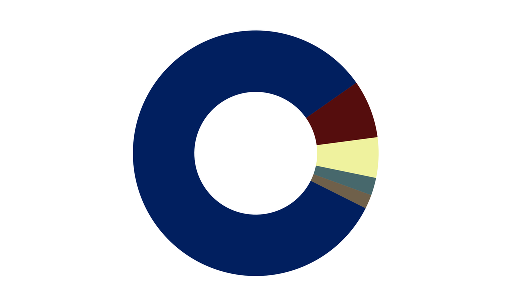

```r
### Load cryptic files
cryptic_df <- readxl::read_xlsx("/Users/irika/Library/CloudStorage/OneDrive-JohnsHopkins/WongLing/Papers/NMD/02_Revisions/TDP43-NMD_Tables_Main.xlsx", sheet = 2) %>% mutate(chr = str_split_i(canonical_splice_junction,":",1))
skiptic_df <- readxl::read_xlsx("/Users/irika/Library/CloudStorage/OneDrive-JohnsHopkins/WongLing/Papers/NMD/02_Revisions/TDP43-NMD_Tables_Main.xlsx", sheet = 3) %>% mutate(type = "skiptic") %>% mutate(chr = str_split_i(skiptic_junction,":",1))

# Set wd for new figures
setwd("/Users/irika/Library/CloudStorage/OneDrive-JohnsHopkins/WongLing/Scripts/NMDi_TDP43kd_repo/")

## Merge cryptic and skiptic dfs
df <- rbind(cryptic_df %>% dplyr::select(gene_symbol,ensembl_id, cryptic_exon_id,chr,
                                         type, Inframe, starts_with("avgPSI"), starts_with("maxPSI")),
                skiptic_df %>% dplyr::select(gene_symbol,ensembl_id, cryptic_exon_id,chr,
                                             type,Inframe, starts_with("avgPSI"), starts_with("maxPSI")))

## Visualize overall characteristics in pie/donut chart form
pieChartFx(df$type, cols = c("#002D72","#69140E","#F2F3AE","#587B7F","#82735C"))
```

```r
# ggsave("output_fig/251224_CE_All.png",device = "png",
#        width = 30, height = 30, units = "cm",limitsize = FALSE)
table(df$type)
```

```
##
##   cassette  exon ext.      polyA    skiptic start site
##        358         33         23         10          8
```

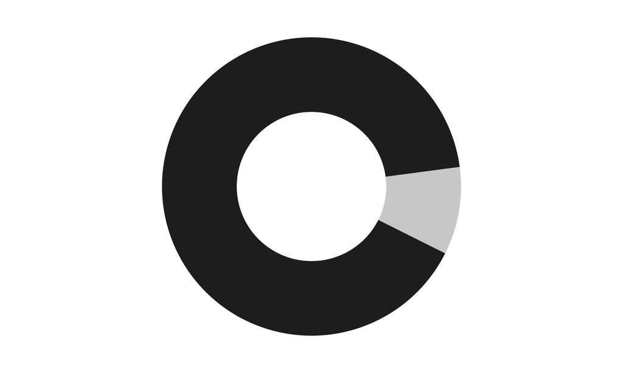

```r
pieChartFx(df$Inframe, cols = c("#262626","#D1D1D1"))
```

```r
# ggsave("output_fig/251224_CE_Inframe.png",device = "png",
#        width = 30, height = 30, units = "cm",limitsize = FALSE)
table(df$Inframe)
```

```
##
##  NA   Y
## 391  41
```

# Visualize the difference in CE inclusion rates with NMDi

```r
# Create a df with CEs labeled as per cut-off for TDP-43kd only PSIs
df_NMD <- df %>% mutate(NMDonly10pct = ifelse(avgPSI_sgTARDBP <= 10, "10pct", "TDPKDonly"),
                        NMDonly5pct = ifelse(avgPSI_sgTARDBP <= 5, "5pct", "TDPKDonly"),
                        NMDonly1pct = ifelse(avgPSI_sgTARDBP <= 1, "1pct", "TDPKDonly")) %>%
  pivot_longer(cols=c("NMDonly10pct","NMDonly5pct","NMDonly1pct"),
               names_to = "NMDonly", values_to = "category",
               names_prefix = "NMDonly") %>%
  mutate(category = ifelse(is.na(category), NMDonly, category),
         category = ifelse(category == "TDPKDonly","TDPKDonly","NMDi"),
         NMDonly = factor(NMDonly, c("10pct","5pct","1pct")))

# Create a df for CEs measurable only in NMDi conditons
nmdOnlyCEs <- df_NMD[which(df_NMD$NMDonly == "1pct" & df_NMD$category == "NMDi"),]
table(df_NMD$NMDonly, df_NMD$category)
```

```
##
##         NMDi TDPKDonly
##   10pct  188       244
##   5pct   123       309
##   1pct    39       393
```

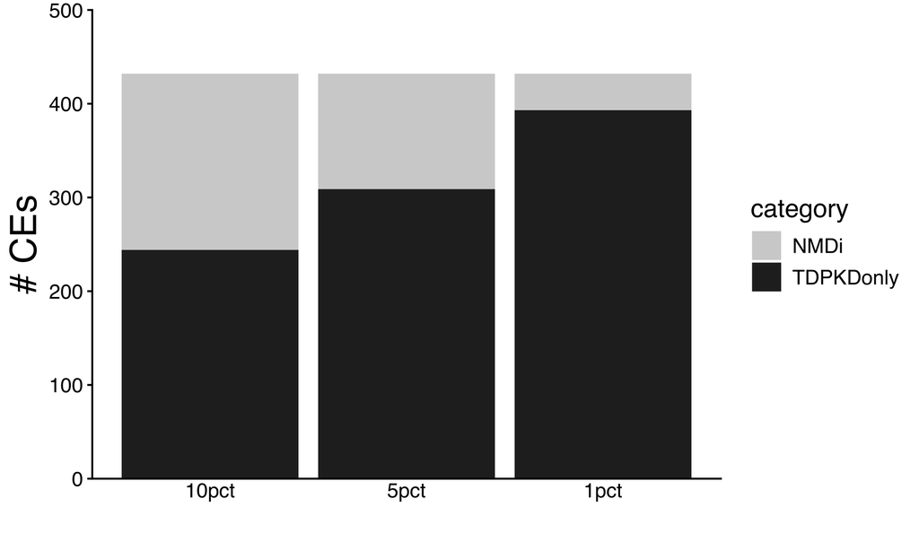

```r
## PLOT: HOW MANY CEs ARE MEASURABLE IN DIFF MINIMUM PSI CONDITIONS
# Figure 1B
df_NMD %>% ggplot(aes(x=NMDonly,fill=category))+geom_bar()+
  theme_classic()+ xlab("") + ylab("# CEs") +
  theme(text = element_text(size = 14, family = "Helvetica"),
        axis.ticks.x = element_blank(),
        axis.title = element_text(size = 20, family = "Helvetica", color = "black")) +
  scale_y_continuous(expand = c(0, 0),limits = c(0,500))+
  scale_fill_manual(values = c("#D1D1D1","#262626"))
```

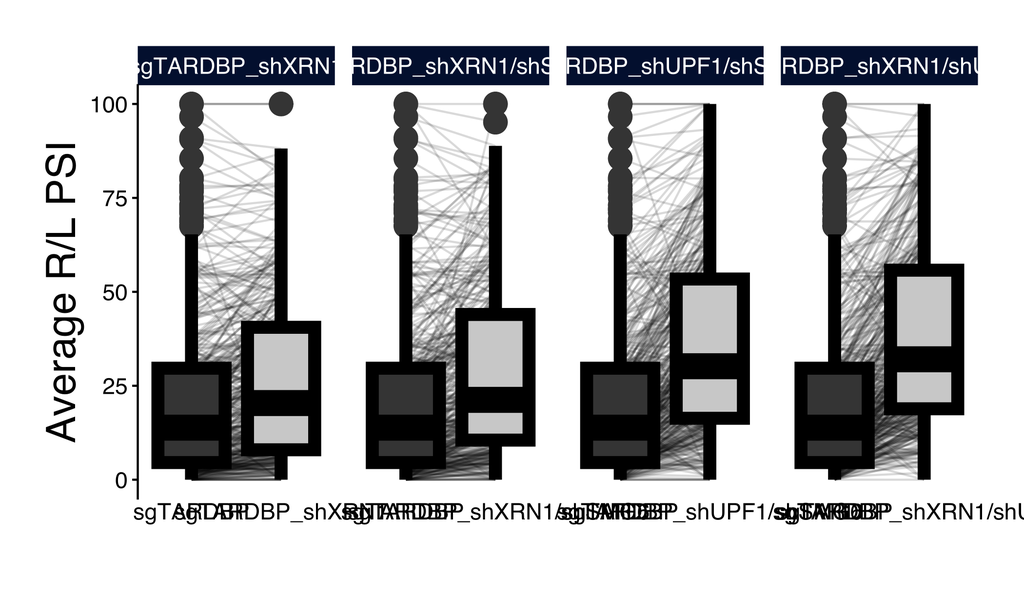

```r
### Plots to look at dPSI as a result of NMDi
# Create new dataframe
df_NMD <- df_NMD %>%
  dplyr::select(gene_symbol,ensembl_id, cryptic_exon_id,type, Inframe, starts_with("avgPSI")) %>%
  pivot_longer(starts_with("avgPSI"), names_to = "condition", names_prefix = "avgPSI_", values_to = "PSI")
df_NMD_avgT <- df_NMD %>% filter(condition == "sgTARDBP")
df_NMD_dNMD_avgNMD <- df_NMD %>% filter(condition != "sgTARDBP") %>%
  mutate(facetCol = condition)
cond <- unique(df_NMD$condition)

for(i in cond){
  df_NMD_dNMD_avgNMD <- rbind(df_NMD_dNMD_avgNMD,
                                  df_NMD_avgT %>% mutate(facetCol = i))
  rm(i)
}

## Difference in mean PSI for each NMDi to TDP-43 kd only condition FIG2C
df_NMD_dNMD_avgNMD %>% filter(str_detect(facetCol, "^sgTARDBP_")) %>%
  mutate(facetCol = factor(facetCol,
                           levels=c("sgTARDBP_shXRN1",
                                    "sgTARDBP_shXRN1/shSMG6",
                                    "sgTARDBP_shUPF1/shSMG6",
                                    "sgTARDBP_shXRN1/shUPF1"))) %>%
  ggplot(aes(x = condition, y = PSI)) +
  geom_line(aes(group=cryptic_exon_id), alpha = 0.15) +
  geom_boxplot(alpha=1, outliers = T, fill = c(rep(c("#444444","#D1D1D1"),4)), color = "black",
               outlier.color = "#444444",outlier.size = 5, linewidth = 3) +
  theme_classic()+ xlab("") + ylab("Average R/L PSI") +
  theme(text = element_text(size = 14, family = "Helvetica"),
        axis.line.x = element_blank(),
        axis.ticks.x = element_blank(),
        axis.title = element_text(size = 20, family = "Helvetica", color = "black"),
        plot.margin = margin(0.8, 0.8, 0.8, 0.8, "cm"),
        strip.background = element_rect(fill = "#02153D", colour = "#02153D"),
        strip.text = element_text(color="white"), panel.spacing = unit(0.3, "cm"))+
  facet_wrap(~ facetCol, scales = "free_x", ncol = 4)
```

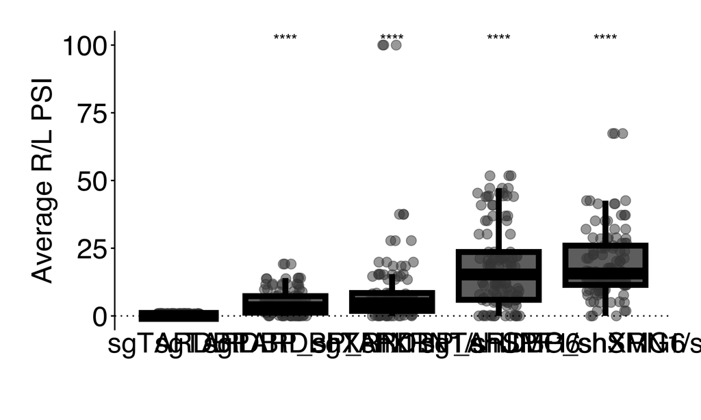

```r
# ggsave("output_fig/251224_NMDi_Effect_Paired.png",device = "png",
#        width = 50, height = 40, units = "cm",limitsize = FALSE)

# 1% NMD CEs increase - Fig S2C
df_NMD_dNMD_avgNMD %>% filter(str_detect(facetCol, "^sgTARDBP")) %>%
  mutate(condition = factor(condition,
                           levels=c("sgTARDBP",
                                    "sgTARDBP_shXRN1",
                                    "sgTARDBP_shXRN1/shSMG6",
                                    "sgTARDBP_shUPF1/shSMG6",
                                    "sgTARDBP_shXRN1/shUPF1"))) %>%
  filter(cryptic_exon_id %in% nmdOnlyCEs$cryptic_exon_id) %>%
  ggplot(aes(x = condition, y = PSI)) +
  geom_point(alpha = 0.5, position = position_jitter(width = 0.2), size=3, color =  "#444444")+
  geom_boxplot(alpha=0.8, outliers = F, fill = "#444444", color = "black",
               outlier.color = "#444444",outlier.size = 1, linewidth=2) +
  scale_color_viridis_d(option = "viridis")+
  theme_classic()+ xlab("") + ylab("Average R/L PSI") +
  theme(text = element_text(size = 25, family = "Helvetica"), legend.position = "none",
        axis.line.x = element_blank(),
        axis.ticks.x = element_blank(),
        axis.title = element_text(size = 20, family = "Helvetica", color = "black"),
        plot.margin = margin(0.8, 0.8, 0.8, 0.8, "cm"),
        strip.background = element_rect(fill = "#02153D", colour = "#02153D"),
        strip.text = element_text(color="white"), panel.spacing = unit(0.3, "cm"))+
  geom_hline(yintercept=0, linetype="dotted")+scale_y_continuous(breaks=c(seq(-50,100,25))) +
    stat_compare_means(label = "p.signif", method = "t.test", ref.group = "sgTARDBP",)
```

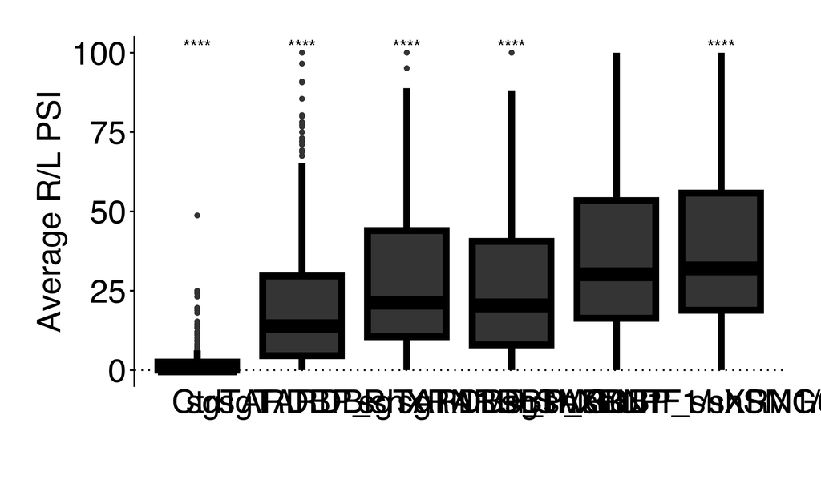

```r
# CE PSI in every condition - Fig S1E
df_NMD %>% filter(condition != "sgCtrl",
                  str_detect(condition, "sgTARDBP|Ctrl")) %>%
  mutate(condition = factor(condition,
                           levels=c("Ctrl",
                                    "sgTARDBP",
                                    "sgTARDBP_shXRN1/shSMG6",
                                    "sgTARDBP_shXRN1",
                                    "sgTARDBP_shUPF1/shSMG6",
                                    "sgTARDBP_shXRN1/shUPF1"))) %>%
  ggplot(aes(x = condition, y = PSI)) +
  geom_boxplot(alpha=1, outliers = T, fill = "#444444", color = "black",
               outlier.color = "#444444",outlier.size = 1,linewidth = 2) +
  theme_classic()+ xlab("") + ylab("Average R/L PSI") +
  theme(text = element_text(size = 25, family = "Helvetica"), legend.position = "none",
        axis.line.x = element_blank(),
        axis.ticks.x = element_blank(),
        axis.title = element_text(size = 20, family = "Helvetica", color = "black"),
        plot.margin = margin(0.8, 0.8, 0.8, 0.8, "cm"),
        strip.background = element_rect(fill = "#02153D", colour = "#02153D"),
        strip.text = element_text(color="white"), panel.spacing = unit(0.3, "cm"))+
  geom_hline(yintercept=0, linetype="dotted")+scale_y_continuous(breaks=c(seq(-50,100,25))) +
    stat_compare_means(label = "p.signif", method = "t.test", ref.group="sgTARDBP_shUPF1/shSMG6",
                       paired = T)
```

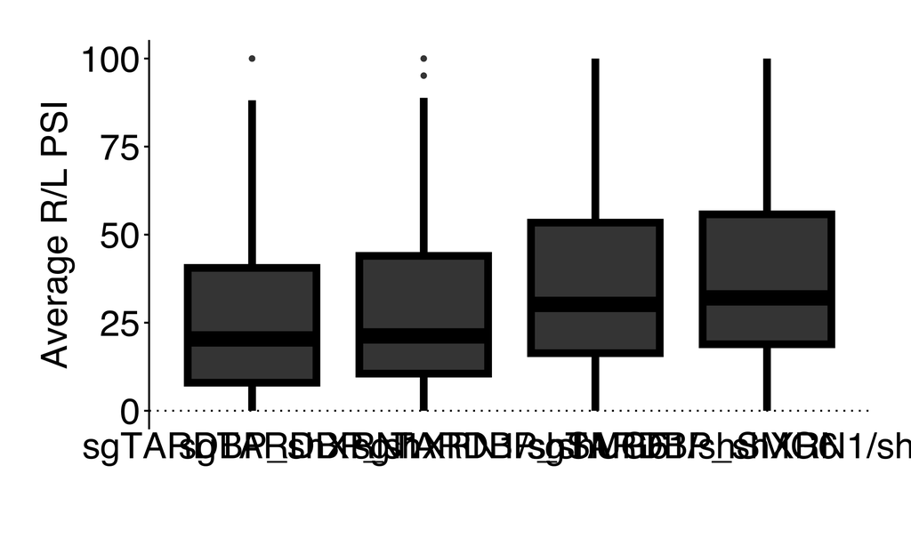

```r
# CE PSI in every condition - Fig S1F
df_NMD %>% filter(condition != "sgCtrl", condition != "sgTARDBP",
                  str_detect(condition, "sgTARDBP_")) %>%
  mutate(condition = factor(condition,
                           levels=c("sgTARDBP_shXRN1",
                                    "sgTARDBP_shXRN1/shSMG6",
                                    "sgTARDBP_shUPF1/shSMG6",
                                    "sgTARDBP_shXRN1/shUPF1"))) %>%
  ggplot(aes(x = condition, y = PSI)) +
  # geom_point(alpha = 0.2, position = position_jitter(width = 0.2), color="#444444")+
  geom_boxplot(alpha=1, outliers = T, fill = "#444444", color = "black",
               outlier.color = "#444444",outlier.size = 1,linewidth = 2) +
  theme_classic()+ xlab("") + ylab("Average R/L PSI") +
  theme(text = element_text(size = 25, family = "Helvetica"), legend.position = "none",
        axis.line.x = element_blank(),
        axis.ticks.x = element_blank(),
        axis.title = element_text(size = 20, family = "Helvetica", color = "black"),
        plot.margin = margin(0.8, 0.8, 0.8, 0.8, "cm"),
        strip.background = element_rect(fill = "#02153D", colour = "#02153D"),
        strip.text = element_text(color="white"), panel.spacing = unit(0.3, "cm"))+
  geom_hline(yintercept=0, linetype="dotted")+scale_y_continuous(breaks=c(seq(-50,100,25))) #+
```

```r
    # stat_compare_means(label = "p.signif", method = "t.test", ref.group = "sgTARDBP_shXRN1")
```

Figure S1D: Cryptic exons/chr –> normalize to number of genes in the chr Use information from GTF file for Release 49 (GRCh38.p14) –> Basic gene annotation

```r
## Load GTF file --> genes only
gencodeInformation <- rtracklayer::import("data/gencode.v49.basic.annotation.gtf")
gencodeInformation <- gencodeInformation[gencodeInformation$type == "gene"]

## Subset to unique genes that are lncRNA, protein coding, or snRNA
unique(gencodeInformation$gene_type)
```

```
##  [1] "lncRNA"                             "transcribed_unprocessed_pseudogene"
##  [3] "miRNA"                              "protein_coding"
##  [5] "processed_pseudogene"               "transcribed_processed_pseudogene"
##  [7] "snRNA"                              "unprocessed_pseudogene"
##  [9] "misc_RNA"                           "TEC"
## [11] "transcribed_unitary_pseudogene"     "snoRNA"
## [13] "scaRNA"                             "rRNA_pseudogene"
## [15] "unitary_pseudogene"                 "rRNA"
## [17] "IG_V_pseudogene"                    "IG_V_gene"
## [19] "IG_C_gene"                          "IG_J_gene"
## [21] "sRNA"                               "ribozyme"
## [23] "translated_processed_pseudogene"    "vault_RNA"
## [25] "TR_C_gene"                          "TR_J_gene"
## [27] "TR_V_gene"                          "TR_V_pseudogene"
## [29] "TR_D_gene"                          "IG_C_pseudogene"
## [31] "TR_J_pseudogene"                    "IG_J_pseudogene"
## [33] "IG_D_gene"                          "IG_pseudogene"
## [35] "artifact"                           "Mt_tRNA"
## [37] "Mt_rRNA"
```

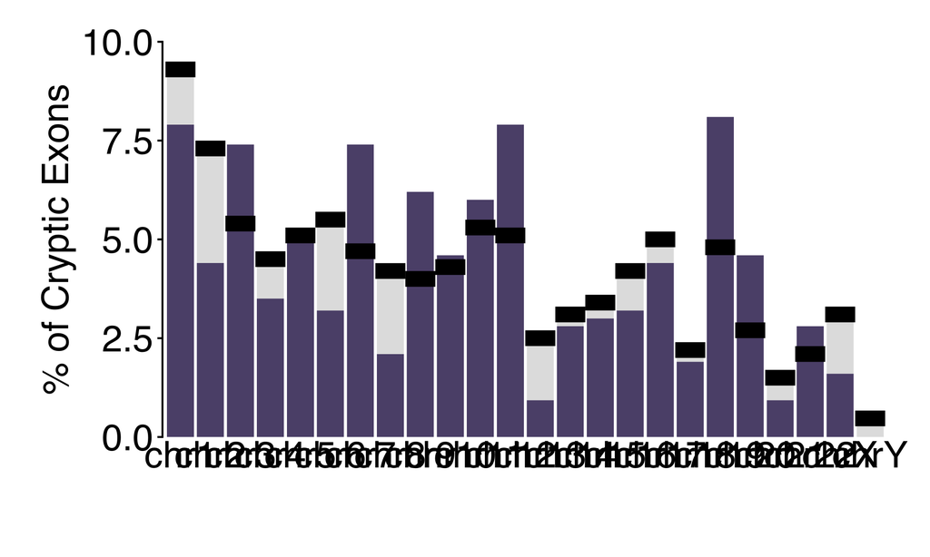

```r
gencodeInformation <- gencodeInformation[gencodeInformation$gene_type %in% c("lncRNA", "protein_coding","snRNA")]

chr_df <- data.frame(table(seqnames(gencodeInformation))) %>% filter(Var1 != "chrM") # Remove mitochondrial

### Graph to compare % CEs on each chromosome and % genes on each chromosome
df_chr <- data.frame(table(df$chr)) %>% full_join(chr_df, by = "Var1") %>%
  mutate(pct_cryptic = signif(100*Freq.x/432,2),
         pct_gene = signif(100*Freq.y/sum(chr_df$Freq),2),
         Var1 = factor(Var1, paste0("chr",c(1:22,"X","Y"))))%>%
  arrange(Var1, levels=paste0("chr",c(1:22,"X","Y")))

df_chr %>%
  ggplot(aes(x=Var1)) +
  geom_col(aes(y = pct_gene),fill="#e1e1e1") +
  geom_col(aes(y = pct_cryptic),fill="#5D5179") +
  theme_classic()+
  xlab("") + ylab("% of Cryptic Exons") +
  scale_y_continuous(expand = c(0, 0), lim = c(0,10)) +
  theme(text = element_text(size = 25, family = "Helvetica", color = "black"),
        axis.line.x = element_blank(),
        axis.ticks.x = element_blank(),
        axis.title = element_text(size = 20, family = "Helvetica", color = "black"),
        plot.margin = margin(0.8, 0.8, 0.8, 0.8, "cm"),
        strip.text = element_text(color="white"), panel.spacing = unit(0.3, "cm"))+
   geom_segment(aes(x = seq(0.5,24,1), xend = seq(1.5,24.5,1),
                    y = pct_gene),
                 color="black", linewidth = 4)
```

```r
# ggsave("output_fig/251224_chrPmbp.png",device = "png",
#        width = 50, height = 25, units = "cm",limitsize = FALSE)
```

## Identify high expressors (cryptic targets)

High expressor cryptic exons have a PSI of at least 70% in at least one condition but the maximum control PSI is 10% in any condition.

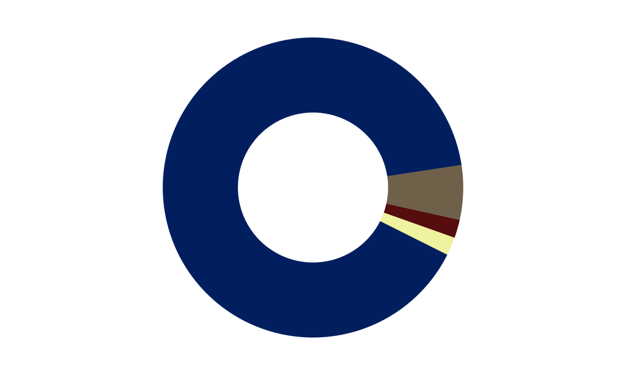

```r
## High expressors
df_high <- df %>% filter(maxPSI_sgTARDBP > 70 &  maxPSI_Ctrl < 10)
# write.csv(df_high,"output_tables/251224_CrypticCoordinates_HighExp.csv")

# There are no skiptics.  - Fig S2B
pieChartFx((df_high %>% mutate(type = factor(type,c("cassette", "start site", "exon ext.", "polyA"))) %>%
              arrange(type))$type,
           cols = c("#002D72","#82735C","#69140E", "#F2F3AE"))
```

```r
table(df_high$type)
```

```
##
##   cassette  exon ext.      polyA start site
##         46          1          1          3
```

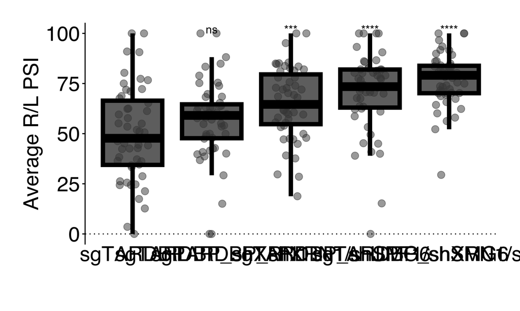

```r
# Fig S2D: High expressor PSI in all conditions
df_high %>%
  pivot_longer(starts_with("avgPSI"),
               names_to = "condition",
               names_prefix = "avgPSI_",
               values_to = "PSI") %>%
  filter(str_detect(condition, "^sgTARDBP")) %>%
  mutate(condition = factor(condition,
                           levels=c("sgTARDBP",
                                    "sgTARDBP_shXRN1",
                                    "sgTARDBP_shXRN1/shSMG6",
                                    "sgTARDBP_shUPF1/shSMG6",
                                    "sgTARDBP_shXRN1/shUPF1"))) %>%
  ggplot(aes(x = condition, y = PSI)) +
  geom_point(alpha = 0.5, position = position_jitter(width = 0.2), size=3, color =  "#444444")+
  geom_boxplot(alpha=0.8, outliers = F, fill = "#444444", color = "black",
               outlier.color = "#444444",outlier.size = 1, linewidth=2) +
  scale_color_viridis_d(option = "viridis")+
  theme_classic()+ xlab("") + ylab("Average R/L PSI") +
  theme(text = element_text(size = 25, family = "Helvetica"), legend.position = "none",
        axis.line.x = element_blank(),
        axis.ticks.x = element_blank(),
        axis.title = element_text(size = 20, family = "Helvetica", color = "black"),
        plot.margin = margin(0.8, 0.8, 0.8, 0.8, "cm"),
        strip.background = element_rect(fill = "#02153D", colour = "#02153D"),
        strip.text = element_text(color="white"), panel.spacing = unit(0.3, "cm"))+
  stat_compare_means(label = "p.signif", method = "t.test", ref.group = "sgTARDBP")+
  geom_hline(yintercept=0, linetype="dotted")+scale_y_continuous(breaks=c(seq(-50,100,25)))
```

## What do the gene expression patterns look like for these cryptic exons?

Using NAUC as a metric of gene expresion as calculated by ASCOT.

First look at high-expressors.

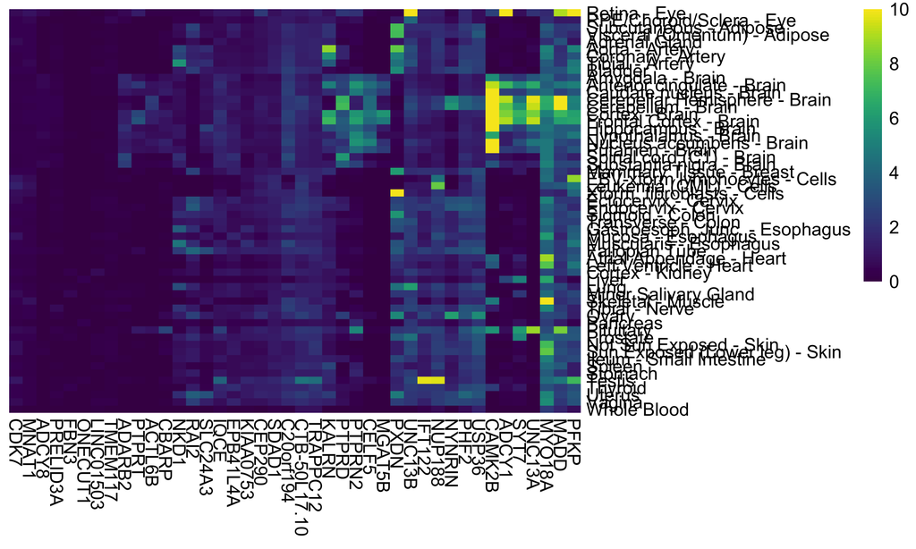

```r
nauc <- fread("/Users/irika/Library/CloudStorage/OneDrive-JohnsHopkins/WongLing/Projects/NMD/NotGitHub/data/gtex_nauc.csv")

## HEAT MAPS
# High expressor gene expression across tissues
df_high <- df %>% filter(maxPSI_sgTARDBP > 70 &  maxPSI_Ctrl < 10)

nauc_highCE <- nauc %>% filter(gene_id %in% df_high$ensembl_id) %>%
  pivot_longer(3:58, names_to = "tissue", values_to = "nauc") %>%
  mutate(nauc = ifelse(nauc >=10, 10, nauc))

nauc_highCE_mat <- nauc_highCE[-1] %>% pivot_wider(names_from="tissue", values_from="nauc") %>% column_to_rownames(var="gene_symbol")

pheatmap(t(as.matrix(nauc_highCE_mat)),
         color = viridis(length(seq(0,10,0.1)),option="D"),
         border_color = NA,
         cluster_rows = F,
         show_rownames = T,
         treeheight_row = 0,
         treeheight_col = 0,
         breaks = seq(0,10,0.1)
         )
```

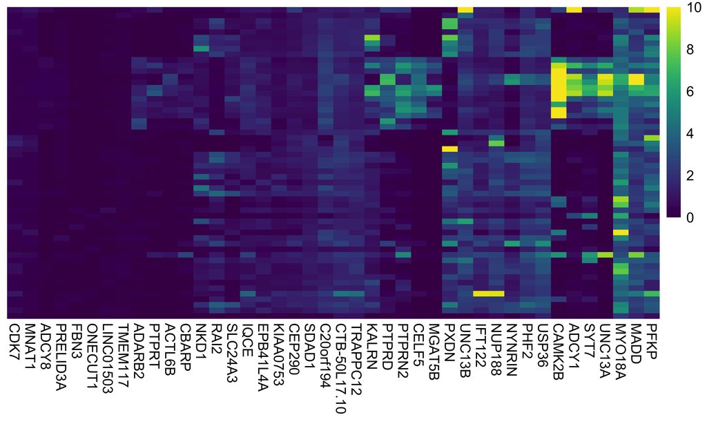

```r
# Create matching PSI graph

orderGenes <- pheatmap(t(as.matrix(nauc_highCE_mat)),
         color = viridis(length(seq(0,10,0.1)),option="D"),
         border_color = NA,
         cluster_rows = F,
         show_rownames = F,
         treeheight_row = 0,
         treeheight_col = 0,
         breaks = seq(0,10,0.1)
         )
```

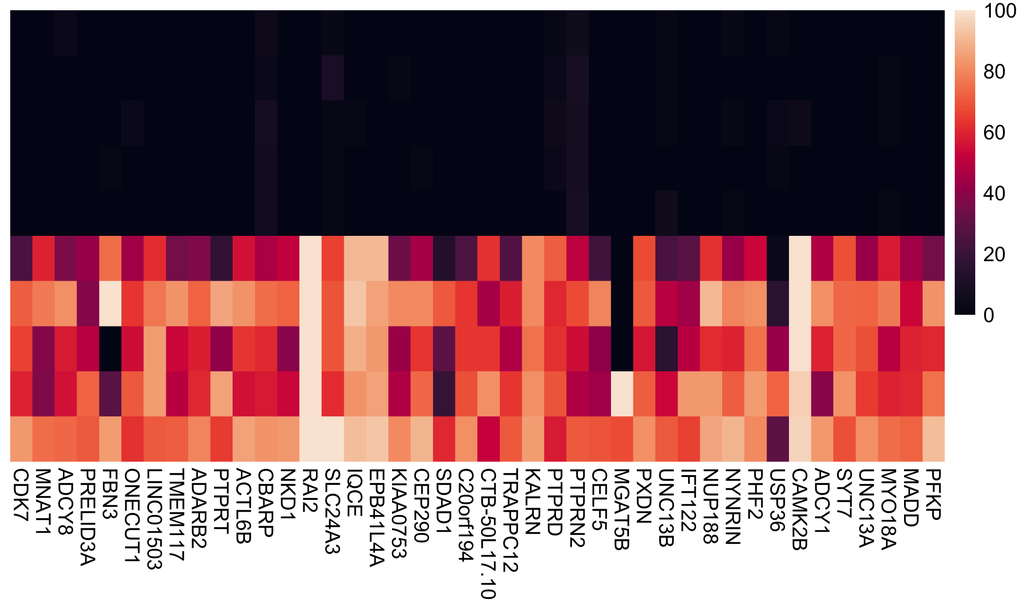

```r
crypticHighOrder <- data.frame(gene = orderGenes$tree_col$labels[orderGenes$tree_col$order])

# Choose highest PSI CE for a gene with multiple in high expressors
maxPSI <- df_high %>% filter(ensembl_id %in% nauc_highCE$gene_id) %>%
  group_by(gene_symbol) %>%
  summarize(max = max(maxPSI_sgTARDBP))

maxCE <- c()
for(i in 1:nrow(maxPSI)){
  maxCE <- append(maxCE, which(df_high$gene_symbol == maxPSI$gene_symbol[i] & df_high$maxPSI_sgTARDBP== maxPSI$max[i]))
}

maxPSI <- df_high[maxCE,]

# Still two duplicates due to same max - rmove the ones at a lower PSI after TDP kd only
maxPSI <- maxPSI %>% filter(!(cryptic_exon_id %in% c("CE140","CE359")))
maxPSI <- maxPSI[,c(1,7:17)]
colnames(maxPSI)[1] = "gene"

# MERGE WITH ORDERED DF
maxPSI$gene[13] = "CTB-50L17.10"
maxPSI$gene[10] = "C20orf194"

crypticHighOrder <- left_join(crypticHighOrder, maxPSI, by = "gene") %>%
  column_to_rownames("gene")

breaksList = seq(0, 100, by = 1)
pheatmap((t(as.matrix(crypticHighOrder[,-6]))),
         color = viridis(length(breaksList),option="F"),
         border_color = NA,
         cluster_rows = F,
         cluster_cols = F,
         show_rownames = F,
         treeheight_row = 0,
         treeheight_col = 0,
         breaks = breaksList
         )
```

NMDi-revealed CEs expression and PSI

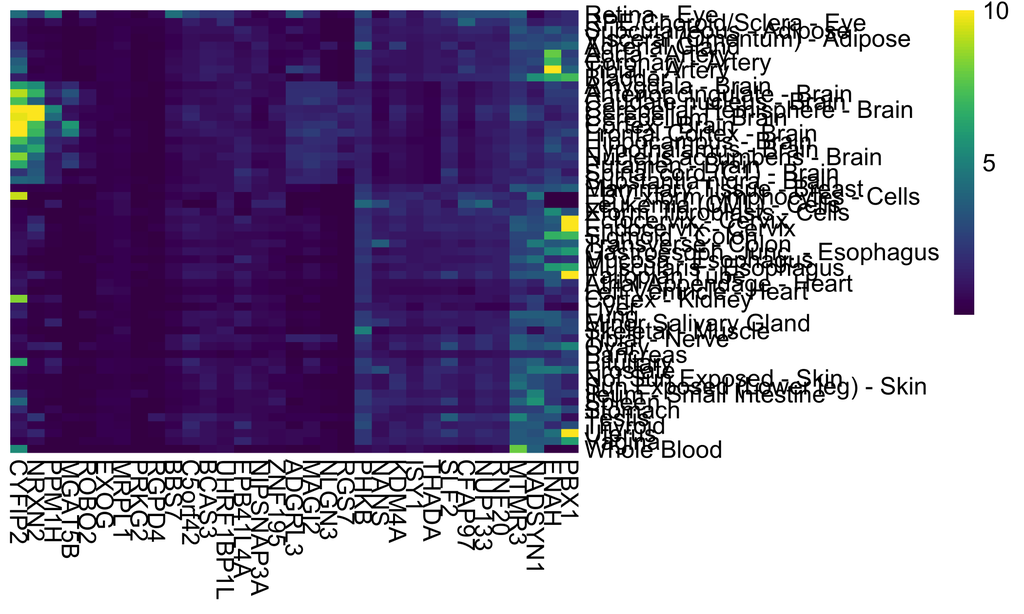

```r
## Subset to CEs with PSI <= 1% after TDP-43 KD only
# all ctrl conditions < 10%
df_NMDce <- df %>% mutate(NMDonly = ifelse(avgPSI_sgTARDBP <= 1, ifelse(maxPSI_Ctrl < 10, "Y", "N"), "N"))
nmdOnlyCEs <- df[which(df_NMDce$NMDonly == "Y"),]

## Table Information
nmdOnlyCEs_df <- df_NMDce %>%
  mutate(NMDonly = ifelse(avgPSI_sgTARDBP <= 10, ifelse(maxPSI_Ctrl < 10, "10pct", "N"), "N"),
         NMDonly = ifelse(avgPSI_sgTARDBP <= 5, ifelse(maxPSI_Ctrl < 10, "5pct", NMDonly), NMDonly),
         NMDonly = ifelse(avgPSI_sgTARDBP <= 1, ifelse(maxPSI_Ctrl < 10, "1pct", NMDonly), NMDonly)) %>%
  filter(NMDonly != "N")

# write.csv(nmdOnlyCEs_df,"output_tables/251224_NMD_CrypticCoordinates.csv", row.names = F)

nauc_NMD <- nauc %>% filter(gene_id %in% nmdOnlyCEs$ensembl_id) %>%
  dplyr::select(-gene_id) %>%
  pivot_longer(2:57,names_to = "tissue", values_to = "nauc") %>%
  mutate(nauc = ifelse(nauc > 10, 10, nauc)) %>%
  pivot_wider(names_from = "tissue", values_from = "nauc") %>%
  column_to_rownames("gene_symbol")

# Plot nauc of all NMD-sensitive CEs
#NAUC
pheatmap(t(as.matrix(nauc_NMD)),
         cluster_cols = T,
         cluster_rows = F,
         fontsize = 12,
         color = viridis(100,option="D"),
         legend_breaks = c(0,5,10),
         border_color = NA,
         display_numbers = F,
         treeheight_col = 0)
```

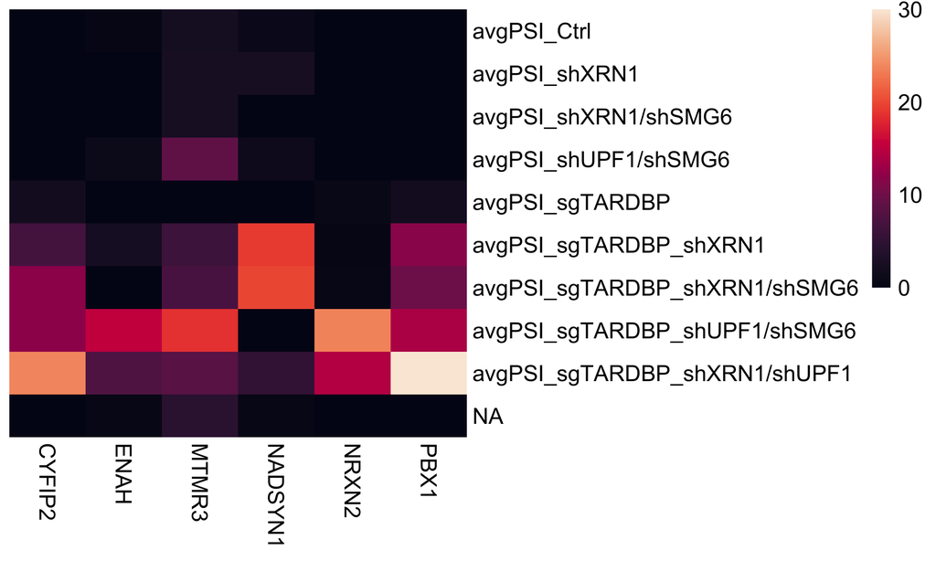

```r
# PSI
df_PSI <- df_NMDce %>%
  filter(gene_symbol %in% c("CYFIP2", "NRXN2", "MTMR3", "NADSYN1", "ENAH", "PBX1")) %>%
  dplyr::select(c(gene_symbol, cryptic_exon_id,starts_with("avg"))) %>%
  filter(!(cryptic_exon_id %in% c("CE092", "CE093","CE266"))) %>% # MANUAL SELECTION OF STRONGEST CE
  dplyr::select(-cryptic_exon_id) %>%
  arrange(gene_symbol, levels = c("CYFIP2", "NRXN2", "MTMR3", "NADSYN1", "ENAH", "PBX1")) %>%
  pivot_longer(starts_with("avgPSI_"), names_to = "cond", values_to = "psi") %>%
  filter(cond != "avgPSI_sgCtrl") %>%
  mutate(cond = factor(cond, c("avgPSI_Ctrl",
                               "avgPSI_shXRN1","avgPSI_shXRN1/shSMG6",
                               "avgPSI_shUPF1/shSMG6","savgPSI_shXRN1/shUPF1",
                               "avgPSI_sgTARDBP",
                               "avgPSI_sgTARDBP_shXRN1", "avgPSI_sgTARDBP_shXRN1/shSMG6",
                               "avgPSI_sgTARDBP_shUPF1/shSMG6", "avgPSI_sgTARDBP_shXRN1/shUPF1"))) %>%
  pivot_wider(names_from = cond, values_from = psi, names_sort = T) %>%
  column_to_rownames("gene_symbol")

# Sets the minimum (0), the maximum (15), and the increasing steps (+1) for the color scale
# Note: if some of your genes are outside of this range, they will appear white on the heatmap
breaksList = seq(0, 30, by = 0.1)

pheatmap(t(as.matrix(df_PSI)),
         cluster_cols = F,
         cluster_rows = F,
         fontsize = 12,
         color = viridis(length(breaksList),option="F"),
         legend_breaks = c(0,10,20,30),
         border_color = NA,
         display_numbers = F,
         treeheight_col = 0,
         breaks= breaksList)
```